# Trajectory checks: stress-testing the AEM–RDA regime workflow

Pilot diagnostics for the EcoIndicators Synthesis manuscript (13 sanctuaries × 7 EOVs)

These are **independent pilot checks**, not the manuscript’s results. They re-implement the workflow shown in the 2026-04-20 working-group deck (monthly anomalies → z-scores → seasonal subsets → asymmetric eigenvector maps (AEM) → forward selection → RDA → fitted-axis “temporal control chart”) from the same extracts (copernicus, erddap) and then ask how the conclusions hold up when a choice is varied or a null model is applied.

```r
librarian::shelf(
  adespatial, dplyr, ecp, ggplot2, glue, here, knitr, lubridate, parallel,
  patchwork, purrr, readr, scales, stringr, tibble, tidyr, vegan,
  quiet = T)
options(readr.show_col_types = F)
set.seed(42)

# paths ----
copernicus_csv <- here("data/copernicus.csv")
erddap_csv     <- here("data/erddap.csv")
dir_chk        <- here("data/trajectory_checks")
dir_fig        <- here("figures/trajectory_checks")
deck_csv       <- file.path(dir_chk, "deck_2026-04-20_r2adj.csv")
null_csv       <- file.path(dir_chk, "null_52.csv")
full_csv       <- file.path(dir_chk, "full_series_aem.csv")
cp_csv         <- file.path(dir_chk, "changepoints.csv")
dir.create(dir_chk, showWarnings = F, recursive = T)
dir.create(dir_fig, showWarnings = F, recursive = T)

# constants ----
N_SUR   <- 200                       # surrogates per analysis
N_CORE  <- max(1, detectCores() - 2)
VARS    <- c("tempSurf", "tempBott", "mixThick", "salinity", "precip", "CHL", "PP")
SEASONS <- c("winter", "spring", "summer", "fall")
# sanctuaries, ordered pacific (n -> s, then islands) to gulf and atlantic (s -> n)
NMS_ORD <- c(
  "OCNMS", "GFNMS", "CBNMS", "MBNMS", "CPNMS", "CINMS", "HIHWNMS", "NMSAS",
  "FGBNMS", "FKNMS", "GRNMS", "MNMS", "SBNMS")
VAR_LUT <- c(
  "thetao_depth=0.49402499" = "tempSurf",
  "bottomT"                 = "tempBott",
  "mlotst"                  = "mixThick",
  "so_depth=0.49402499"     = "salinity",
  "precipitation"           = "precip",
  "CHL"                     = "CHL",
  "PP"                      = "PP")

# plot theme: recessive chrome, thin marks ----
PAL <- list(
  surface = "#fcfcfb", ink = "#0b0b0b", ink2 = "#52514e", muted = "#898781",
  grid    = "#e1e0d9", axis = "#c3c2b7", blue = "#2a78d6", orange = "#eb6834")
PAL_DIV  <- c("#104281", "#2a78d6", "#9ec5f4", "#f0efec", "#f3b3ad", "#e34948", "#8f1d1c")
PAL_SEQ  <- c("#f0efec", "#cde2fb", "#86b6ef", "#3987e5", "#1c5cab", "#0d366b")
PAL_BAND <- c("#86b6ef", "#3987e5", "#1c5cab", "#0d366b")   # ordinal, short -> long time scale

theme_chk <- function(base_size = 10) {
  theme_minimal(base_size = base_size) +
    theme(
      plot.background    = element_rect(fill = PAL$surface, color = NA),
      panel.background   = element_rect(fill = PAL$surface, color = NA),
      panel.grid.major   = element_line(color = PAL$grid, linewidth = 0.25),
      panel.grid.minor   = element_blank(),
      axis.text          = element_text(color = PAL$muted),
      axis.title         = element_text(color = PAL$ink2),
      plot.title         = element_text(color = PAL$ink, face = "bold", size = rel(1.1)),
      plot.subtitle      = element_text(color = PAL$ink2),
      plot.caption       = element_text(color = PAL$muted, hjust = 0),
      plot.title.position = "plot",
      strip.text         = element_text(color = PAL$ink, face = "bold", hjust = 0),
      legend.position    = "top",
      legend.justification = "left",
      legend.title       = element_text(color = PAL$ink2),
      legend.text        = element_text(color = PAL$ink2))
}
save_fig <- function(p, name, width = 9, height = 5) {
  ggsave(file.path(dir_fig, name), p, width = width, height = height, dpi = 200, bg = PAL$surface)
  p
}
```

## Data

Sanctuary-wide monthly means of seven variables for thirteen sanctuaries. Where the multi-year (`my`) and interim (`myint`) GLORYS12 streams overlap, the multi-year value is kept.

```r
d_wide <- bind_rows(read_csv(copernicus_csv), read_csv(erddap_csv)) |>
  filter(
    nms  %in% NMS_ORD,
    var  %in% names(VAR_LUT),
    stat == "mean") |>
  mutate(
    date   = as_date(time),
    var    = recode(var, !!!VAR_LUT),
    is_int = str_detect(dataset, "myint")) |>
  arrange(nms, var, date, is_int) |>
  distinct(nms, var, date, .keep_all = T) |>
  select(nms, date, var, value) |>
  pivot_wider(names_from = var, values_from = value) |>
  arrange(nms, date)

d_wide |>
  pivot_longer(all_of(VARS), names_to = "var") |>
  drop_na(value) |>
  group_by(var) |>
  summarize(
    first = min(date), last = max(date), sanctuaries = n_distinct(nms),
    .groups = "drop") |>
  kable(caption = "Coverage of the seven analysis variables")
```

Coverage of the seven analysis variables

| var | first | last | sanctuaries |
| --- | --- | --- | --- |
| CHL | 1997-09-01 | 2026-03-01 | 13 |
| PP | 1997-09-01 | 2026-03-01 | 13 |
| mixThick | 1993-01-01 | 2026-02-01 | 13 |
| precip | 1998-01-01 | 2025-09-01 | 13 |
| salinity | 1993-01-01 | 2026-02-01 | 13 |
| tempBott | 1993-01-01 | 2026-02-01 | 13 |
| tempSurf | 1993-01-01 | 2026-02-01 | 13 |

## Helper functions

```r
season_of <- function(mo) case_when(
  mo %in% c(12, 1, 2) ~ "winter",
  mo %in% 3:5         ~ "spring",
  mo %in% 6:8         ~ "summer",
  TRUE                ~ "fall")

# monthly anomalies as in the deck: subtract the calendar-month mean over the window
get_anom <- function(nms_i, date_beg = as_date("2002-09-01"), date_end = as_date("2025-08-31")) {
  d_wide |>
    filter(nms == nms_i, date >= date_beg, date <= date_end) |>
    select(date, all_of(VARS)) |>
    drop_na() |>
    mutate(mo = month(date)) |>
    group_by(mo) |>
    mutate(across(all_of(VARS), \(x) x - mean(x))) |>
    ungroup() |>
    mutate(season = season_of(mo))
}

# aem basis for a regular series of n points: the first k_max eigenfunctions (the deck uses
# aem 1-24 for the 69-point seasonal subsets) or, if k_max is NULL, all with positive moran's i
aem_cache <- new.env()
get_aem <- function(n, k_max = 24) {
  key <- paste(n, k_max)
  if (is.null(aem_cache[[key]])) {
    a <- aem.time(n, moran = is.null(k_max))
    E <- as.data.frame(a$aem)
    names(E) <- paste0("AEM", seq_len(ncol(E)))
    aem_cache[[key]] <- if (is.null(k_max)) E[, a$Moran$obs > -1 / (n - 1), drop = FALSE] else E[, seq_len(k_max), drop = FALSE]
  }
  aem_cache[[key]]
}

# aem -> forward selection (double stopping criterion) on z-scored responses
fit_aem_rda <- function(Y, nperm = 999, alpha = 0.05, k_max = 24) {
  E   <- get_aem(nrow(Y), k_max)
  Ys  <- scale(Y)
  r2g <- RsquareAdj(rda(Ys, E))$adj.r.squared
  fs  <- tryCatch(
    forward.sel(Ys, E, alpha = alpha, adjR2thresh = r2g, nperm = nperm, verbose = FALSE),
    error = \(e) NULL)
  list(Ys = Ys, E = E, sel = fs, n = nrow(Y))
}

# rda on the leading selected aems with p <= alpha (selection order does not depend on alpha,
# so a stricter alpha is a prefix of the alpha = 0.05 selection)
get_rda <- function(fit, alpha = 0.05) {
  if (is.null(fit$sel)) return(NULL)
  keep <- cumsum(fit$sel$pvalue > alpha) == 0
  if (!any(keep)) return(NULL)
  rda(fit$Ys, fit$E[, fit$sel$variables[keep], drop = FALSE])
}

# indices where two curves cross (the deck's regime boundaries)
crossings <- function(a, b) {
  s <- sign(a - b)
  s <- s[s != 0]
  which(diff(s) != 0)
}

# summary of a fit at each alpha, incl. regimes under both sign conventions for axis ii
summarize_fit <- function(fit, alphas = c(0.05, 0.02)) {
  map_dfr(alphas, \(al) {
    m <- get_rda(fit, al)
    if (is.null(m))
      return(tibble(alpha = al, r2a = 0, n_aem = 0L, aems = "", n_reg = 1L, n_reg_flip = 1L, cross = "", cross_flip = ""))
    k    <- sum(cumsum(fit$sel$pvalue > al) == 0)
    aems <- paste(fit$sel$order[seq_len(k)], collapse = ",")
    r2a  <- RsquareAdj(m)$adj.r.squared
    if (length(eigenvals(m, model = "constrained")) < 2)
      return(tibble(alpha = al, r2a = r2a, n_aem = k, aems = aems, n_reg = 1L, n_reg_flip = 1L, cross = "", cross_flip = ""))
    lc <- scores(m, display = "lc", choices = 1:2, scaling = 1)
    i1 <- crossings(lc[, 1],  lc[, 2])
    i2 <- crossings(lc[, 1], -lc[, 2])
    tibble(
      alpha = al, r2a = r2a, n_aem = k, aems = aems,
      n_reg = length(i1) + 1L, n_reg_flip = length(i2) + 1L,
      cross = paste(i1 + 1, collapse = ","), cross_flip = paste(i2 + 1, collapse = ","))
  })
}

# surrogates with no time-localized shift by construction ----
detrend <- function(X) {
  t   <- seq_len(nrow(X))
  fit <- lm(X ~ t)
  list(trend = fitted(fit), resid = residuals(fit))
}
# linear trend + ar(1) noise with cross-correlated innovations
sur_ar1 <- function(X) {
  dt  <- detrend(X); R <- dt$resid; n <- nrow(R); p <- ncol(R)
  phi <- apply(R, 2, \(x) acf(x, lag.max = 1, plot = FALSE)$acf[2])
  inn <- R[-1, ] - sweep(R[-n, ], 2, phi, `*`)
  Z   <- matrix(rnorm((n + 50) * p), ncol = p) %*% chol(cov(inn))
  S   <- matrix(0, n + 50, p)
  for (i in 2:(n + 50)) S[i, ] <- phi * S[i - 1, ] + Z[i, ]
  dt$trend + S[-(1:50), ]
}
# linear trend + phase-randomized residuals (same random phases for all variables,
# so every auto- and cross-spectrum is preserved but nothing is localized in time)
sur_phase <- function(X) {
  dt  <- detrend(X); R <- dt$resid; n <- nrow(R)
  k   <- floor((n - 1) / 2)
  ph  <- runif(k, 0, 2 * pi)
  rot <- rep(1 + 0i, n)
  rot[2:(k + 1)]     <- exp(1i * ph)
  rot[n:(n - k + 1)] <- exp(-1i * ph)
  dt$trend + Re(mvfft(mvfft(R) * rot, inverse = TRUE)) / n
}

# calendar-month standardized anomalies over the full common record (1998-01..2025-09):
# removes the seasonal cycle in both mean and variance without splitting the series
get_z <- function() {
  d_wide |>
    filter(date >= as_date("1998-01-01"), date <= as_date("2025-09-30")) |>
    select(nms, date, all_of(VARS)) |>
    drop_na() |>
    mutate(
      mo = month(date),
      yr = year(date),
      across(c(CHL, PP, mixThick), log),
      precip = sqrt(precip)) |>
    group_by(nms, mo) |>
    mutate(across(all_of(VARS), \(x) {
      s <- sd(x)
      if (s < 1e-8) rep(0, length(x)) else (x - mean(x)) / s })) |>
    ungroup()
}
z <- get_z()
```

## 1. What the AEM basis is

For a regular series, AEM *k* crosses zero *k* times: it completes one full oscillation in 2*L*/*k* years, where *L* is the record length. The deck labels AEM *k* as *L*/*k* years, which is the length of one monotonic excursion (half a cycle). AEM 1 is therefore a monotonic curve that is almost indistinguishable from a straight line, and AEM 2 completes exactly one oscillation in the record. The eigenvalues fall as 1/*k*², which is the spectrum of a random walk.

```r
n_s  <- 69                                   # jun-aug 2003-2025
L_yr <- 22.2
a69  <- aem.time(n_s, moran = FALSE)
tibble(
  AEM                 = 1:8,
  `zero crossings`    = apply(a69$aem[, 1:8], 2, \(v) sum(diff(sign(v)) != 0)),
  `deck label (yr)`   = round(L_yr / (1:8), 1),
  `full cycle (yr)`   = round(2 * L_yr / (1:8), 1),
  `eigenvalue / first` = round(a69$values[1:8] / a69$values[1], 3),
  `1 / k^2`           = round(1 / (1:8)^2, 3)) |>
  kable(caption = glue(
    "AEM basis for n = {n_s}. Correlation of AEM 1 with time = ",
    "{round(abs(cor(a69$aem[, 1], seq_len(n_s))), 3)}."))
```

AEM basis for n = 69. Correlation of AEM 1 with time = 0.993.

| AEM | zero crossings | deck label (yr) | full cycle (yr) | eigenvalue / first | 1 / k^2 |
| --- | --- | --- | --- | --- | --- |
| 1 | 1 | 22.2 | 44.4 | 1.000 | 1.000 |
| 2 | 2 | 11.1 | 22.2 | 0.250 | 0.250 |
| 3 | 3 | 7.4 | 14.8 | 0.111 | 0.111 |
| 4 | 4 | 5.6 | 11.1 | 0.063 | 0.062 |
| 5 | 5 | 4.4 | 8.9 | 0.040 | 0.040 |
| 6 | 6 | 3.7 | 7.4 | 0.028 | 0.028 |
| 7 | 7 | 3.2 | 6.3 | 0.021 | 0.020 |
| 8 | 8 | 2.8 | 5.6 | 0.016 | 0.016 |

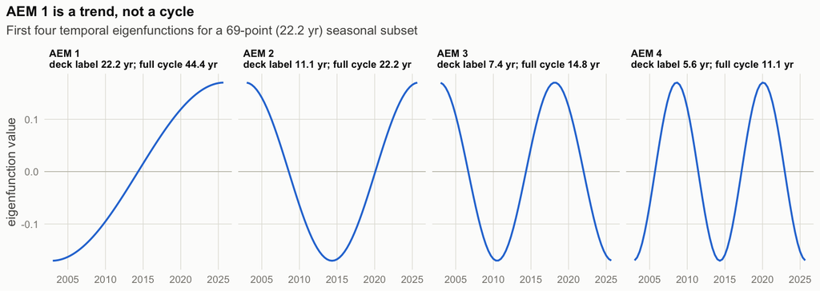

```r
d_aem <- as_tibble(a69$aem[, 1:4]) |>
  setNames(glue("AEM {1:4}\ndeck label {round(L_yr / 1:4, 1)} yr; full cycle {round(2 * L_yr / 1:4, 1)} yr")) |>
  mutate(year = 2003 + (row_number() - 1) / 3) |>
  pivot_longer(-year, names_to = "aem")

p <- ggplot(d_aem, aes(year, value)) +
  geom_hline(yintercept = 0, color = PAL$axis, linewidth = 0.3) +
  geom_line(color = PAL$blue, linewidth = 0.7) +
  facet_wrap(~aem, nrow = 1) +
  labs(
    title = "AEM 1 is a trend, not a cycle",
    subtitle = "First four temporal eigenfunctions for a 69-point (22.2 yr) seasonal subset",
    x = NULL, y = "eigenfunction value") +
  theme_chk()
save_fig(p, "fig_aem_basis.png", 9, 3.2)
```

## 2. Replication of the flagship analysis (HIHWNMS, summer)

Candidates are AEM 1–24 as in the deck. Forward selection at α = 0.05 retains slightly more eigenfunctions than the deck; α = 0.02 reproduces the deck’s 52 models most closely (section 4), so both are carried through.

```r
ALPHA_DECK <- 0.02      # reproduces the deck's models most closely

a_hi   <- get_anom("HIHWNMS") |> filter(season == "summer")
fit_hi <- fit_aem_rda(as.matrix(a_hi[, VARS]))
```

```
Procedure stopped (alpha criteria): pvalue for variable 10 is 0.058000 (> 0.050000)
```

```r
m_hi   <- get_rda(fit_hi, ALPHA_DECK)

deck_hi <- tibble(
  variables  = paste0("AEM", c(1, 3, 2, 14, 4, 8, 16, 5)),
  deck_R2adj = c(0.1527, 0.1399, 0.0554, 0.0309, 0.0299, 0.0169, 0.0154, 0.0118))

fit_hi$sel |>
  as_tibble() |>
  mutate(this_R2adj = c(AdjR2Cum[1], diff(AdjR2Cum))) |>
  select(variables, this_R2adj, pvalue) |>
  full_join(deck_hi, by = "variables") |>
  mutate(across(where(is.numeric), \(x) round(x, 4))) |>
  kable(caption = glue(
    "Forward-selected AEMs (alpha = 0.05), this notebook vs. the deck (slide 12). n = {nrow(a_hi)}. ",
    "Total adjusted R2: {round(RsquareAdj(get_rda(fit_hi, 0.05))$adj.r.squared, 3)} at alpha 0.05, ",
    "{round(RsquareAdj(m_hi)$adj.r.squared, 3)} at alpha {ALPHA_DECK}; deck 0.453. ",
    "Differences reflect the refreshed extract and unspecified pre-processing details."))
```

Forward-selected AEMs (alpha = 0.05), this notebook vs. the deck (slide 12). n = 69. Total adjusted R2: 0.504 at alpha 0.05, 0.477 at alpha 0.02; deck 0.453. Differences reflect the refreshed extract and unspecified pre-processing details.

| variables | this_R2adj | pvalue | deck_R2adj |
| --- | --- | --- | --- |
| AEM1 | 0.1530 | 0.001 | 0.1527 |
| AEM3 | 0.1416 | 0.001 | 0.1399 |
| AEM2 | 0.0560 | 0.001 | 0.0554 |
| AEM14 | 0.0446 | 0.001 | 0.0309 |
| AEM4 | 0.0319 | 0.002 | 0.0299 |
| AEM16 | 0.0290 | 0.003 | 0.0154 |
| AEM8 | 0.0213 | 0.007 | 0.0169 |
| AEM13 | 0.0146 | 0.030 | NA |
| AEM5 | 0.0120 | 0.032 | 0.0118 |

## 3. Are axis-crossing regimes invariant?

The control chart draws the fitted site scores of canonical axes I and II through time and places a regime boundary wherever the two curves cross. Eigenvectors have no intrinsic sign: reflecting an axis gives an equally valid ordination. If boundaries move when an axis is reflected, they describe a plotting convention rather than the system.

```r
get_regimes <- function(m, dates, scaling = 1, flip2 = 1) {
  lc <- scores(m, display = "lc", choices = 1:2, scaling = scaling)
  i  <- crossings(lc[, 1], flip2 * lc[, 2])
  tibble(
    scaling    = scaling,
    `axis II`  = if_else(flip2 == 1, "as returned", "reflected"),
    regimes    = length(i) + 1,
    boundaries = paste(format(dates[i + 1], "%Y-%m"), collapse = ", "))
}
expand_grid(alpha = c(ALPHA_DECK, 0.05), scaling = c(1, 2), flip2 = c(1, -1)) |>
  pmap_dfr(\(alpha, scaling, flip2)
    get_regimes(get_rda(fit_hi, alpha), a_hi$date, scaling, flip2) |> mutate(alpha = alpha, .before = 1)) |>
  kable(caption = "HIHWNMS summer: regime boundaries under equivalent presentations of the same RDA. The deck reports boundaries at Jul 2009, Jul 2010 and Jul 2018.")
```

HIHWNMS summer: regime boundaries under equivalent presentations of the same RDA. The deck reports boundaries at Jul 2009, Jul 2010 and Jul 2018.

| alpha | scaling | axis II | regimes | boundaries |
| --- | --- | --- | --- | --- |
| 0.02 | 1 | as returned | 6 | 2006-06, 2014-07, 2015-07, 2016-07, 2024-07 |
| 0.02 | 1 | reflected | 6 | 2009-07, 2010-06, 2015-08, 2016-08, 2018-07 |
| 0.02 | 2 | as returned | 6 | 2006-06, 2014-06, 2015-07, 2016-07, 2024-06 |
| 0.02 | 2 | reflected | 8 | 2006-08, 2007-06, 2009-06, 2010-07, 2015-08, 2016-07, 2018-07 |
| 0.05 | 1 | as returned | 6 | 2006-06, 2014-07, 2015-07, 2016-07, 2024-08 |
| 0.05 | 1 | reflected | 6 | 2009-07, 2009-08, 2015-07, 2016-07, 2018-07 |
| 0.05 | 2 | as returned | 8 | 2006-07, 2014-06, 2015-07, 2016-07, 2022-07, 2022-08, 2024-07 |
| 0.05 | 2 | reflected | 6 | 2009-06, 2010-06, 2015-07, 2016-07, 2018-07 |

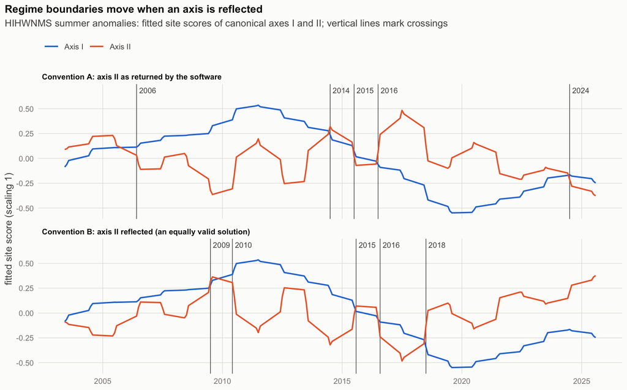

```r
lc <- scores(m_hi, display = "lc", choices = 1:2, scaling = 1)
conv_lab <- c(
  a = "Convention A: axis II as returned by the software",
  b = "Convention B: axis II reflected (an equally valid solution)")
d_cc <- bind_rows(
  tibble(conv = conv_lab["a"], date = a_hi$date, `Axis I` = lc[, 1], `Axis II` =  lc[, 2]),
  tibble(conv = conv_lab["b"], date = a_hi$date, `Axis I` = lc[, 1], `Axis II` = -lc[, 2])) |>
  pivot_longer(c(`Axis I`, `Axis II`), names_to = "axis", values_to = "score")
d_bd <- bind_rows(
  tibble(conv = conv_lab["a"], date = a_hi$date[crossings(lc[, 1],  lc[, 2]) + 1]),
  tibble(conv = conv_lab["b"], date = a_hi$date[crossings(lc[, 1], -lc[, 2]) + 1])) |>
  mutate(lab = format(date, "%Y"))
y_top <- max(abs(d_cc$score)) * 1.25

p <- ggplot(d_cc, aes(date, score)) +
  geom_vline(data = d_bd, aes(xintercept = date), color = PAL$ink2, linewidth = 0.3) +
  geom_text(data = d_bd, aes(x = date, y = y_top, label = lab),
            color = PAL$ink2, size = 2.8, hjust = -0.15, check_overlap = TRUE) +
  geom_line(aes(color = axis), linewidth = 0.7) +
  facet_wrap(~conv, ncol = 1) +
  scale_color_manual(values = c("Axis I" = PAL$blue, "Axis II" = PAL$orange), name = NULL) +
  labs(
    title = "Regime boundaries move when an axis is reflected",
    subtitle = "HIHWNMS summer anomalies: fitted site scores of canonical axes I and II; vertical lines mark crossings",
    x = NULL, y = "fitted site score (scaling 1)") +
  theme_chk()
save_fig(p, "fig_control_chart_sign.png", 9, 5.6)
```

## 4. Do crossings exceed what “trend + red noise” produces?

All 52 season × sanctuary analyses were re-fit, then compared with surrogate series that contain a linear trend plus autocorrelated noise and, by construction, **no** time-localized shift: `trend_ar1` (AR(1) noise with cross-correlated innovations) and `trend_phase` (phase-randomized residuals that preserve every auto- and cross-spectrum).

```r
if (!file.exists(null_csv)) {
  jobs <- expand_grid(nms = NMS_ORD, season = SEASONS)
  run_job <- function(j) {
    set.seed(1000 + j)
    a   <- get_anom(jobs$nms[j])
    X   <- as.matrix(a[, VARS])
    idx <- which(a$season == jobs$season[j])
    to_dates <- \(s) map_chr(s, \(x) if (x == "") "" else
      paste(format(a$date[idx][as.integer(str_split(x, ",")[[1]])], "%Y-%m"), collapse = ","))
    fit <- \(M, nperm) summarize_fit(fit_aem_rda(M[idx, ], nperm = nperm))
    bind_rows(
      fit(X, 999) |> mutate(type = "observed", rep = 0L),
      map_dfr(seq_len(N_SUR), \(r) fit(sur_ar1(X),   199) |> mutate(type = "trend_ar1",   rep = r)),
      map_dfr(seq_len(N_SUR), \(r) fit(sur_phase(X), 199) |> mutate(type = "trend_phase", rep = r))) |>
      mutate(
        nms = jobs$nms[j], season = jobs$season[j], n = length(idx),
        cross_dates      = if_else(type == "observed", to_dates(cross), ""),
        cross_dates_flip = if_else(type == "observed", to_dates(cross_flip), ""))
  }
  invisible(get_aem(69))
  mclapply(seq_len(nrow(jobs)), run_job, mc.cores = N_CORE) |>
    bind_rows() |>
    select(nms, season, n, type, rep, alpha, r2a, n_aem, aems, n_reg, n_reg_flip, cross_dates, cross_dates_flip) |>
    write_csv(null_csv)
}
d_null <- read_csv(null_csv, col_types = cols(
  aems = "c", cross_dates = "c", cross_dates_flip = "c")) |>
  mutate(across(c(aems, cross_dates, cross_dates_flip), \(x) replace_na(x, "")))
d_obs  <- d_null |> filter(type == "observed")
d_deck <- read_csv(deck_csv)

# replication fidelity across all 52 analyses, by alpha
d_obs |>
  left_join(d_deck |> rename(n_aem_deck = n_aem), by = c("nms", "season")) |>
  group_by(alpha) |>
  summarize(
    `r (adj. R2, here vs deck)`         = round(cor(r2a, r2adj_pct), 2),
    `median adj. R2 here (%)`           = round(100 * median(r2a), 1),
    `median adj. R2 deck (%)`           = median(r2adj_pct),
    `median abs. difference (points)`   = round(median(abs(100 * r2a - r2adj_pct)), 1),
    `median AEMs here`                  = median(n_aem),
    `median AEMs deck`                  = median(n_aem_deck),
    .groups = "drop") |>
  kable(caption = "How closely this notebook reproduces the deck's 52 models (slide 33)")
```

How closely this notebook reproduces the deck’s 52 models (slide 33)

| alpha | r (adj. R2, here vs deck) | median adj. R2 here (%) | median adj. R2 deck (%) | median abs. difference (points) | median AEMs here | median AEMs deck |
| --- | --- | --- | --- | --- | --- | --- |
| 0.02 | 0.87 | 24.8 | 24.7 | 3.0 | 5 | 7 |
| 0.05 | 0.88 | 32.1 | 24.7 | 5.1 | 9 | 7 |

```r
has_aem1 <- \(x) str_detect(paste0(",", x, ","), ",1,")
d_sum <- d_null |>
  filter(type != "observed") |>
  group_by(alpha, nms, season, type) |>
  summarize(
    reg_med = median(n_reg), reg_lo = quantile(n_reg, 0.05), reg_hi = quantile(n_reg, 0.95),
    r2a_med = median(r2a),   r2a_lo = quantile(r2a, 0.05),   r2a_hi = quantile(r2a, 0.95),
    aem1    = mean(has_aem1(aems)),
    .groups = "drop") |>
  left_join(
    d_obs |> select(alpha, nms, season, reg_obs = n_reg, reg_obs_flip = n_reg_flip, r2a_obs = r2a, aems_obs = aems),
    by = c("alpha", "nms", "season"))

d_sum |>
  group_by(alpha, type) |>
  summarize(
    `observed regimes per analysis, median (range)` = glue("{median(reg_obs)} ({min(reg_obs)}-{max(reg_obs)})"),
    `surrogate regimes per analysis, median`        = median(reg_med),
    `observed regime count inside surrogate 5-95%`  = glue("{sum(reg_obs >= reg_lo & reg_obs <= reg_hi)} of {n()}"),
    `observed regime count above surrogate 95%`     = glue("{sum(reg_obs > reg_hi)} of {n()}"),
    `observed adj. R2 above surrogate 95%`          = glue("{sum(r2a_obs > r2a_hi)} of {n()}"),
    `observed analyses selecting AEM 1`             = glue("{sum(has_aem1(aems_obs))} of {n()}"),
    `surrogates selecting AEM 1 (%)`                = round(100 * mean(aem1)),
    .groups = "drop") |>
  kable(caption = glue("Observed analyses vs. no-shift surrogates ({N_SUR} per analysis)"))
```

Observed analyses vs. no-shift surrogates (200 per analysis)

| alpha | type | observed regimes per analysis, median (range) | surrogate regimes per analysis, median | observed regime count inside surrogate 5-95% | observed regime count above surrogate 95% | observed adj. R2 above surrogate 95% | observed analyses selecting AEM 1 | surrogates selecting AEM 1 (%) |
| --- | --- | --- | --- | --- | --- | --- | --- | --- |
| 0.02 | trend_ar1 | 7 (2-21) | 8.0 | 51 of 52 | 1 of 52 | 10 of 52 | 46 of 52 | 85 |
| 0.02 | trend_phase | 7 (2-21) | 8.0 | 49 of 52 | 2 of 52 | 2 of 52 | 46 of 52 | 84 |
| 0.05 | trend_ar1 | 9 (2-18) | 10.0 | 48 of 52 | 3 of 52 | 12 of 52 | 49 of 52 | 92 |
| 0.05 | trend_phase | 9 (2-18) | 9.5 | 45 of 52 | 4 of 52 | 2 of 52 | 49 of 52 | 92 |

```r
d_obs |>
  group_by(alpha) |>
  summarize(
    `regimes, axis II as returned` = glue("{sum(n_reg)} in total; median {median(n_reg)}"),
    `regimes, axis II reflected`   = glue("{sum(n_reg_flip)} in total; median {median(n_reg_flip)}"),
    `analyses with identical boundaries under both conventions` = glue("{sum(cross_dates == cross_dates_flip)} of {n()}"),
    .groups = "drop") |>
  kable(caption = "Sensitivity of crossing-defined regimes to the sign of axis II, all 52 analyses")
```

Sensitivity of crossing-defined regimes to the sign of axis II, all 52 analyses

| alpha | regimes, axis II as returned | regimes, axis II reflected | analyses with identical boundaries under both conventions |
| --- | --- | --- | --- |
| 0.02 | 387 in total; median 7 | 407 in total; median 8 | 0 of 52 |
| 0.05 | 483 in total; median 9 | 447 in total; median 9 | 0 of 52 |

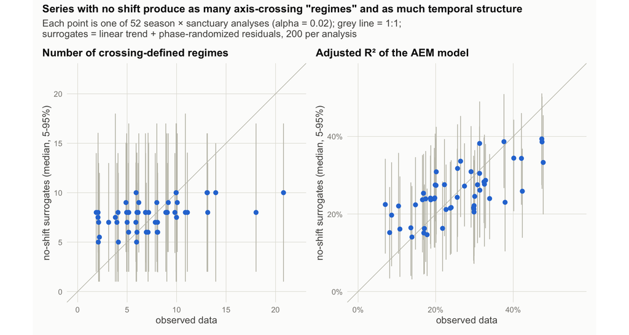

```r
d_plot <- d_sum |> filter(type == "trend_phase", alpha == ALPHA_DECK)
lim_r  <- c(0, max(d_plot$reg_hi, d_plot$reg_obs) + 1)
p1 <- ggplot(d_plot, aes(reg_obs, reg_med)) +
  geom_abline(slope = 1, intercept = 0, color = PAL$axis, linewidth = 0.3) +
  geom_linerange(aes(ymin = reg_lo, ymax = reg_hi), color = PAL$axis, linewidth = 0.4,
                 position = position_jitter(width = 0.2, height = 0, seed = 1)) +
  geom_point(color = PAL$blue, size = 1.8,
             position = position_jitter(width = 0.2, height = 0, seed = 1)) +
  coord_equal(xlim = lim_r, ylim = lim_r) +
  labs(
    title = "Number of crossing-defined regimes",
    x = "observed data", y = "no-shift surrogates (median, 5-95%)") +
  theme_chk()
lim_a <- c(0, max(d_plot$r2a_hi, d_plot$r2a_obs) + 0.05)
p2 <- ggplot(d_plot, aes(r2a_obs, r2a_med)) +
  geom_abline(slope = 1, intercept = 0, color = PAL$axis, linewidth = 0.3) +
  geom_linerange(aes(ymin = r2a_lo, ymax = r2a_hi), color = PAL$axis, linewidth = 0.4) +
  geom_point(color = PAL$blue, size = 1.8) +
  scale_x_continuous(labels = label_percent()) +
  scale_y_continuous(labels = label_percent()) +
  coord_equal(xlim = lim_a, ylim = lim_a) +
  labs(
    title = "Adjusted R² of the AEM model",
    x = "observed data", y = "no-shift surrogates (median, 5-95%)") +
  theme_chk()
p <- (p1 | p2) +
  plot_annotation(
    title = "Series with no shift produce as many axis-crossing \"regimes\" and as much temporal structure",
    subtitle = glue(
      "Each point is one of 52 season × sanctuary analyses (alpha = {ALPHA_DECK}); grey line = 1:1;\n",
      "surrogates = linear trend + phase-randomized residuals, {N_SUR} per analysis"),
    theme = theme_chk())
save_fig(p, "fig_null_regimes.png", 9, 4.8)
```

## 5. Do known events appear in sanctuary-mean monthly anomalies?

Anomalies here are standardized by calendar month over 1998-01 to 2025-09 (chlorophyll, primary production and mixed-layer depth log-transformed; precipitation square-root-transformed), so the seasonal cycle is removed in both mean and variance without splitting the series. Event windows are from the manuscript’s event catalog; they are **not** used in computing anything shown.

```r
# lab_row staggers labels of events that are close in time
events <- tribble(
  ~nms,      ~event,                                   ~beg,         ~end,         ~lab_row,
  "CINMS",   "1997-98 El Niño",                        "1998-01-01", "1998-06-30", 1,
  "CINMS",   "2014-16 marine heatwave",                "2014-01-01", "2016-08-31", 1,
  "HIHWNMS", "2015 heatwave",                          "2015-07-01", "2015-11-30", 1,
  "HIHWNMS", "2019 heatwave",                          "2019-06-01", "2019-12-31", 1,
  "FKNMS",   "2010 cold winter (Jan cold snap)",       "2010-01-01", "2010-03-31", 1,
  "FKNMS",   "2023 heatwave",                          "2023-06-01", "2023-09-30", 1,
  "FGBNMS",  "Hurricane Ike (Sep 2008)",               "2008-09-01", "2008-10-31", 2,
  "FGBNMS",  "2010 cold winter",                       "2010-01-01", "2010-04-30", 1,
  "FGBNMS",  "Jul 2016 mortality event (hypoxia)",     "2016-07-01", "2016-07-31", 2,
  "FGBNMS",  "Hurricane Harvey (Sep 2017)",            "2017-09-01", "2017-10-31", 1,
  "GRNMS",   "2003 summer cold event",                 "2003-07-01", "2003-08-31", 1,
  "GRNMS",   "2010 cold winter",                       "2010-01-01", "2010-03-31", 1,
  "SBNMS",   "2012 heatwave",                          "2012-01-01", "2012-12-31", 1) |>
  mutate(across(c(beg, end), as_date))

sigma_from_d2 <- function(d2, p) qnorm(pchisq(d2, df = p) / 2 + 0.5)
z <- z |>
  group_by(nms) |>
  group_modify(\(d, k) {
    X  <- as.matrix(d[, VARS])
    d2 <- mahalanobis(X, colMeans(X), cov(X))
    d |> mutate(sigma = sigma_from_d2(d2, length(VARS)), rank_mv = rank(-d2))
  }) |>
  ungroup()

events |>
  rowwise() |>
  mutate(s = list(
    z |>
      filter(nms == .env$nms, date >= beg, date <= end) |>
      summarize(
        months            = n(),
        across(all_of(VARS), \(x) x[which.max(abs(x))]),
        `best rank of 333` = min(rank_mv)))) |>
  unnest(s) |>
  mutate(across(all_of(VARS), \(x) round(x, 1)), window = glue("{format(beg, '%Y-%m')} to {format(end, '%Y-%m')}")) |>
  select(nms, event, window, months, all_of(VARS), `best rank of 333`) |>
  kable(caption = "Most extreme standardized anomaly (SD units) of each variable inside each event window, and the best multivariate rank (1 = most unusual month of 333)")
```

Most extreme standardized anomaly (SD units) of each variable inside each event window, and the best multivariate rank (1 = most unusual month of 333)

| nms | event | window | months | tempSurf | tempBott | mixThick | salinity | precip | CHL | PP | best rank of 333 |
| --- | --- | --- | --- | --- | --- | --- | --- | --- | --- | --- | --- |
| CINMS | 1997-98 El Niño | 1998-01 to 1998-06 | 6 | 2.1 | 3.7 | 2.5 | -2.6 | 2.5 | -1.7 | -1.6 | 1 |
| CINMS | 2014-16 marine heatwave | 2014-01 to 2016-08 | 32 | 3.0 | 3.0 | 1.9 | -1.7 | 4.2 | -2.5 | -2.4 | 4 |
| HIHWNMS | 2015 heatwave | 2015-07 to 2015-11 | 5 | 2.5 | -1.2 | -2.8 | -1.4 | 4.1 | -1.5 | -1.7 | 3 |
| HIHWNMS | 2019 heatwave | 2019-06 to 2019-12 | 7 | 2.4 | 1.3 | -2.1 | -2.0 | 2.3 | 2.6 | 2.8 | 9 |
| FKNMS | 2010 cold winter (Jan cold snap) | 2010-01 to 2010-03 | 3 | -3.4 | -3.2 | 1.7 | -3.3 | 1.5 | -0.8 | -1.4 | 4 |
| FKNMS | 2023 heatwave | 2023-06 to 2023-09 | 4 | 2.7 | 2.7 | -0.7 | 1.9 | -1.2 | 2.2 | 2.2 | 28 |
| FGBNMS | Hurricane Ike (Sep 2008) | 2008-09 to 2008-10 | 2 | -2.2 | 1.9 | 1.9 | -0.6 | -1.1 | 1.3 | 1.3 | 11 |
| FGBNMS | 2010 cold winter | 2010-01 to 2010-04 | 4 | -2.8 | -2.1 | 2.1 | -1.7 | 2.1 | 3.7 | 3.5 | 2 |
| FGBNMS | Jul 2016 mortality event (hypoxia) | 2016-07 to 2016-07 | 1 | 1.8 | 0.2 | 0.8 | -0.8 | -0.3 | 1.8 | 2.0 | 49 |
| FGBNMS | Hurricane Harvey (Sep 2017) | 2017-09 to 2017-10 | 2 | -2.3 | -1.1 | -0.8 | 0.6 | -1.6 | 1.3 | 1.2 | 50 |
| GRNMS | 2003 summer cold event | 2003-07 to 2003-08 | 2 | -2.6 | -2.9 | -1.0 | -1.3 | -1.2 | 0.9 | 1.0 | 28 |
| GRNMS | 2010 cold winter | 2010-01 to 2010-03 | 3 | -2.1 | -2.0 | 0.7 | -0.3 | 1.4 | 1.4 | 1.2 | 83 |
| SBNMS | 2012 heatwave | 2012-01 to 2012-12 | 12 | 2.8 | 2.1 | -1.7 | -1.3 | -1.7 | 3.0 | 3.3 | 9 |

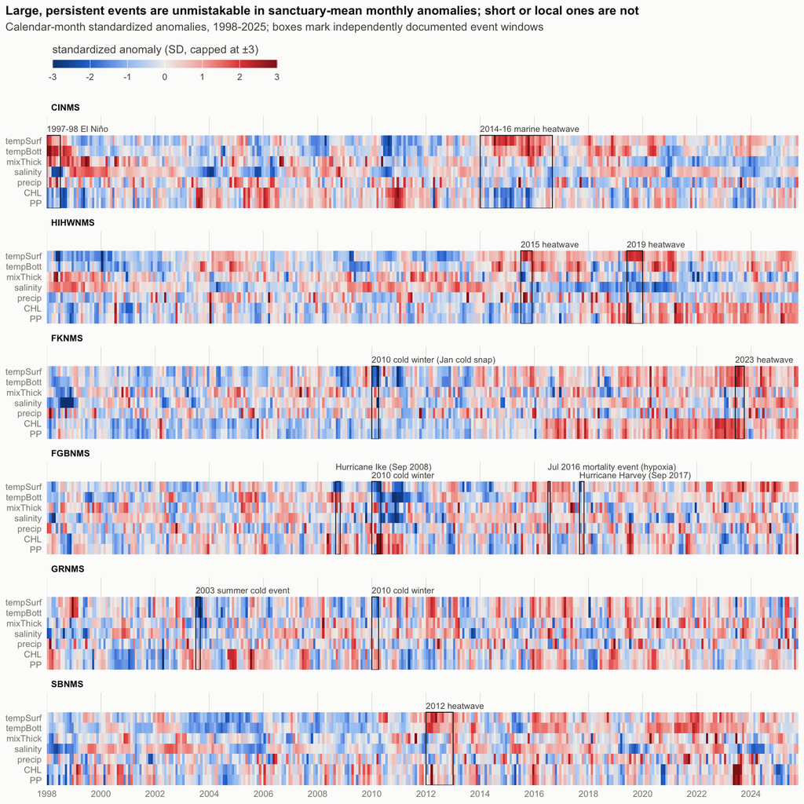

```r
nms_ev <- c("CINMS", "HIHWNMS", "FKNMS", "FGBNMS", "GRNMS", "SBNMS")
d_strip <- z |>
  filter(nms %in% nms_ev) |>
  select(nms, date, all_of(VARS)) |>
  pivot_longer(all_of(VARS), names_to = "var", values_to = "z") |>
  mutate(
    nms = factor(nms, nms_ev),
    var = factor(var, rev(VARS)),
    x   = year(date) + (month(date) - 0.5) / 12,
    z   = pmax(pmin(z, 3), -3))
d_ev <- events |>
  mutate(
    nms  = factor(nms, nms_ev),
    xmin = year(beg) + (month(beg) - 1) / 12,
    xmax = year(end) + month(end) / 12)

p <- ggplot(d_strip, aes(x, as.numeric(var))) +
  geom_raster(aes(fill = z)) +
  geom_rect(data = d_ev, inherit.aes = FALSE,
            aes(xmin = xmin, xmax = xmax, ymin = 0.5, ymax = 7.5),
            fill = NA, color = PAL$ink, linewidth = 0.35) +
  geom_text(data = d_ev, inherit.aes = FALSE,
            aes(x = xmin, y = 7.35 + 0.8 * lab_row, label = event),
            hjust = 0, size = 2.7, color = PAL$ink2) +
  facet_wrap(~nms, ncol = 1) +
  scale_fill_gradientn(
    colors = PAL_DIV, limits = c(-3, 3), breaks = -3:3,
    name = "standardized anomaly (SD, capped at ±3)",
    guide = guide_colorbar(barwidth = 14, barheight = 0.5, title.position = "top")) +
  scale_y_continuous(breaks = seq_along(VARS), labels = rev(VARS), limits = c(0.5, 9.4), expand = c(0, 0)) +
  scale_x_continuous(breaks = seq(1998, 2026, 2), expand = c(0, 0)) +
  labs(
    title = "Large, persistent events are unmistakable in sanctuary-mean monthly anomalies; short or local ones are not",
    subtitle = "Calendar-month standardized anomalies, 1998-2025; boxes mark independently documented event windows",
    x = NULL, y = NULL) +
  theme_chk() +
  theme(panel.grid = element_blank())
save_fig(p, "fig_event_strips.png", 10, 10)
```

## 6. One analysis per sanctuary instead of four

Running the same AEM–RDA on the full monthly series (n = 333) resolves sub-annual to multi-decadal structure in one model per sanctuary. Selected eigenfunctions are grouped into four time-scale bands by their full-cycle period (2*L*/*k*).

```r
if (!file.exists(full_csv)) {
  fit_full <- function(nms_i) {
    d   <- z |> filter(nms == nms_i) |> arrange(date)
    Y   <- as.matrix(d[, VARS])
    E   <- get_aem(nrow(Y), k_max = NULL)
    r2g <- RsquareAdj(rda(Y, E))$adj.r.squared
    fs  <- forward.sel(Y, E, alpha = 0.05, adjR2thresh = r2g, nperm = 499, verbose = FALSE)
    tibble(nms = nms_i, n = nrow(Y), k = fs$order, r2a_inc = c(fs$AdjR2Cum[1], diff(fs$AdjR2Cum)))
  }
  invisible(get_aem(333, k_max = NULL))
  mclapply(NMS_ORD, fit_full, mc.cores = N_CORE) |>
    bind_rows() |>
    write_csv(full_csv)
}
BANDS <- c("< 1.5 yr", "1.5-8 yr (interannual)", "8-15 yr (decadal)", "> 15 yr (trend-like)")
d_full <- read_csv(full_csv) |>
  mutate(
    period_yr = 2 * (n / 12) / k,
    band      = cut(period_yr, c(0, 1.5, 8, 15, Inf), labels = BANDS),
    nms       = factor(nms, rev(NMS_ORD)))
d_band <- d_full |>
  group_by(nms, band) |>
  summarize(r2a = sum(r2a_inc), .groups = "drop")
d_tot <- d_full |>
  group_by(nms) |>
  summarize(r2a = sum(r2a_inc), n_aem = n(), .groups = "drop")

d_band |>
  mutate(r2a = round(100 * r2a, 1)) |>
  pivot_wider(names_from = band, values_from = r2a, values_fill = 0, names_sort = T) |>
  left_join(d_tot |> mutate(`total adj. R2 (%)` = round(100 * r2a, 1)) |> select(nms, `total adj. R2 (%)`, `AEMs selected` = n_aem), by = "nms") |>
  arrange(desc(nms)) |>
  kable(caption = "Full-series AEM–RDA (n = 333 months per sanctuary): adjusted R² (%) by time-scale band")
```

Full-series AEM–RDA (n = 333 months per sanctuary): adjusted R² (%) by time-scale band

| nms | < 1.5 yr | 1.5-8 yr (interannual) | 8-15 yr (decadal) | > 15 yr (trend-like) | total adj. R2 (%) | AEMs selected |
| --- | --- | --- | --- | --- | --- | --- |
| OCNMS | 10.8 | 12.3 | 3.4 | 5.1 | 31.6 | 36 |
| GFNMS | 14.2 | 14.9 | 5.0 | 8.1 | 42.2 | 55 |
| CBNMS | 13.9 | 16.7 | 5.2 | 6.8 | 42.6 | 54 |
| MBNMS | 11.3 | 16.2 | 4.4 | 11.3 | 43.2 | 41 |
| CPNMS | 12.0 | 22.2 | 4.5 | 11.3 | 49.9 | 56 |
| CINMS | 10.0 | 25.4 | 6.1 | 14.7 | 56.2 | 56 |
| HIHWNMS | 10.5 | 10.2 | 15.4 | 17.8 | 53.9 | 43 |
| NMSAS | 19.4 | 22.7 | 6.6 | 15.6 | 64.4 | 73 |
| FGBNMS | 19.3 | 18.1 | 5.1 | 5.0 | 47.6 | 69 |
| FKNMS | 13.0 | 11.7 | 1.0 | 21.9 | 47.6 | 54 |
| GRNMS | 20.0 | 14.3 | 2.0 | 3.4 | 39.7 | 61 |
| MNMS | 15.1 | 21.0 | 1.2 | 9.3 | 46.6 | 59 |
| SBNMS | 15.0 | 22.8 | 3.4 | 8.7 | 50.0 | 62 |

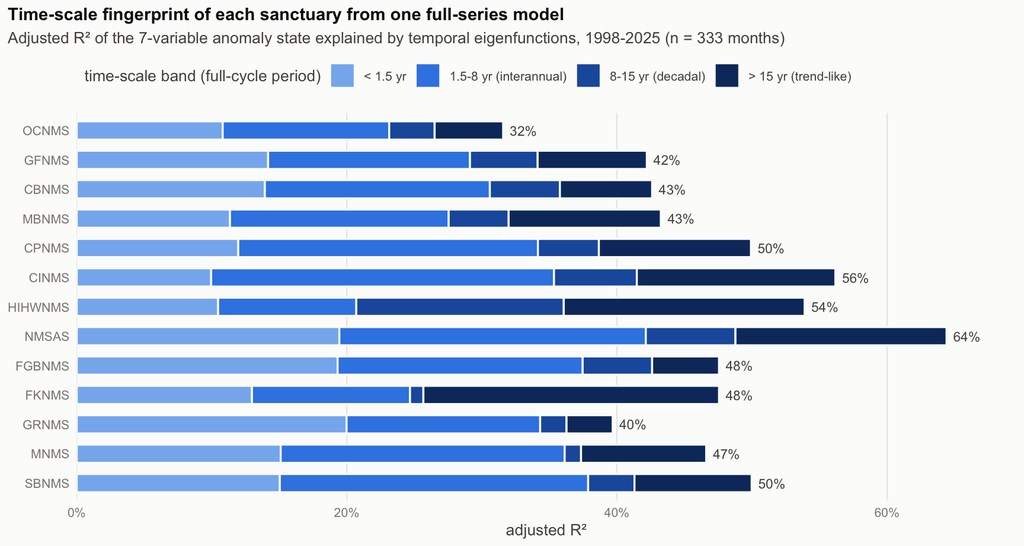

```r
p <- ggplot(d_band, aes(r2a, nms)) +
  geom_col(aes(fill = band), width = 0.62, color = PAL$surface, linewidth = 0.6,
           position = position_stack(reverse = TRUE)) +
  geom_text(data = d_tot, aes(x = r2a, label = percent(r2a, accuracy = 1)),
            hjust = -0.25, size = 3, color = PAL$ink2) +
  scale_fill_manual(values = setNames(PAL_BAND, BANDS), name = "time-scale band (full-cycle period)") +
  scale_x_continuous(labels = label_percent(), expand = expansion(mult = c(0, 0.08))) +
  labs(
    title = "Time-scale fingerprint of each sanctuary from one full-series model",
    subtitle = "Adjusted R² of the 7-variable anomaly state explained by temporal eigenfunctions, 1998-2025 (n = 333 months)",
    x = "adjusted R²", y = NULL) +
  theme_chk() +
  theme(panel.grid.major.y = element_blank())
save_fig(p, "fig_timescale_bands.png", 9, 4.8)
```

### Distribution-free change points and a chronology prototype

E-divisive (`ecp::e.divisive`) finds multivariate change points without reference to ordination axes. Annual means are used for the chronology because monthly anomalies are autocorrelated, which inflates detections.

```r
if (!file.exists(cp_csv)) {
  cp_monthly <- function(nms_i) {
    d  <- z |> filter(nms == nms_i) |> arrange(date)
    i  <- e.divisive(as.matrix(d[, VARS]), sig.lvl = 0.01, R = 499, min.size = 36)$estimates
    i  <- i[i > 1 & i <= nrow(d)]
    tibble(nms = nms_i, cp_monthly = paste(format(d$date[i], "%Y-%m"), collapse = ", "))
  }
  cp_annual <- function(nms_i) {
    d  <- z |> filter(nms == nms_i, yr <= 2024) |>
      group_by(yr) |> summarize(across(all_of(VARS), mean), .groups = "drop")
    i  <- e.divisive(as.matrix(d[, VARS]), sig.lvl = 0.05, R = 999, min.size = 4)$estimates
    i  <- i[i > 1 & i <= nrow(d)]
    tibble(nms = nms_i, cp_annual = paste(d$yr[i], collapse = ", "))
  }
  left_join(
    mclapply(NMS_ORD, cp_monthly, mc.cores = N_CORE) |> bind_rows(),
    mclapply(NMS_ORD, cp_annual,  mc.cores = N_CORE) |> bind_rows(), by = "nms") |>
    write_csv(cp_csv)
}
d_cp <- read_csv(cp_csv, col_types = "ccc")
d_cp |>
  mutate(nms = factor(nms, NMS_ORD)) |>
  arrange(nms) |>
  kable(caption = "E-divisive change points: monthly anomalies (min. segment 36 months, alpha 0.01) and annual means (min. 4 years, alpha 0.05; value = first year of the new segment)")
```

E-divisive change points: monthly anomalies (min. segment 36 months, alpha 0.01) and annual means (min. 4 years, alpha 0.05; value = first year of the new segment)

| nms | cp_monthly | cp_annual |
| --- | --- | --- |
| OCNMS | 2007-03, 2014-09, 2019-10 | 2014 |
| GFNMS | 2003-01, 2006-09, 2014-02, 2017-05, 2022-07 | 2003, 2007, 2014 |
| CBNMS | 2003-01, 2006-09, 2014-02, 2017-05, 2022-07 | 2014 |
| MBNMS | 2003-01, 2006-09, 2013-12, 2022-07 | 2003, 2007, 2014 |
| CPNMS | 2003-03, 2006-08, 2009-08, 2013-11, 2016-11, 2022-07 | 2003, 2014 |
| CINMS | 2003-04, 2006-08, 2009-12, 2014-01, 2019-08, 2022-09 | 2003, 2014 |
| HIHWNMS | 2003-03, 2007-05, 2012-09, 2015-09, 2021-03 | 2003, 2008, 2016, 2021 |
| NMSAS | 2003-10, 2008-02, 2013-04, 2017-02, 2020-12 | 2008 |
| FGBNMS | 2005-02, 2008-05, 2011-05, 2015-01, 2018-10, 2022-03 | 2015 |
| FKNMS | 2004-01, 2008-11, 2013-10, 2016-10, 2020-04 | 2014 |
| GRNMS | 2002-12, 2006-05, 2015-11, 2020-12 | 2003, 2011 |
| MNMS | 2003-04, 2006-08, 2009-08, 2014-01, 2017-05, 2021-09 | 2014 |
| SBNMS | 2002-12, 2006-01, 2011-06, 2017-03, 2020-03 | 2010 |

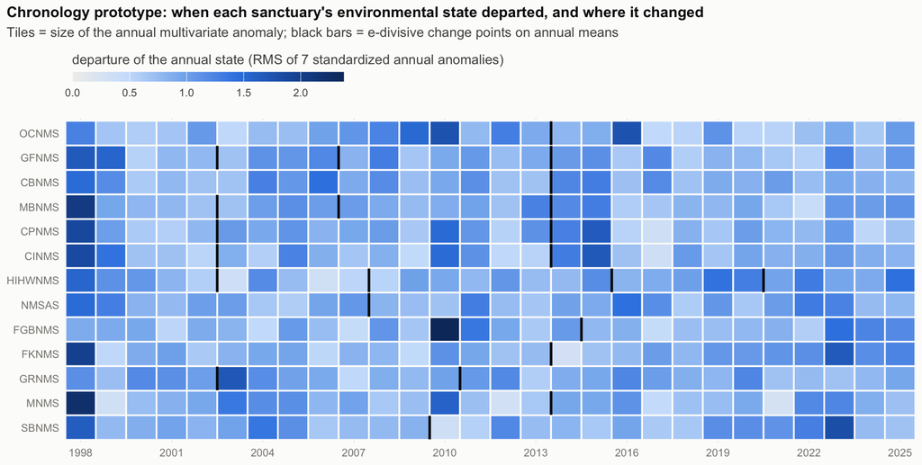

```r
ann <- z |>
  group_by(nms, yr) |>
  summarize(across(all_of(VARS), mean), .groups = "drop") |>
  group_by(nms) |>
  mutate(across(all_of(VARS), \(x) x / sd(x))) |>
  ungroup()
d_chr <- ann |>
  mutate(
    rms = sqrt(rowMeans(across(all_of(VARS), \(x) x^2))),
    nms = factor(nms, rev(NMS_ORD)))
d_cpa <- d_cp |>
  separate_longer_delim(cp_annual, ", ") |>
  filter(!is.na(cp_annual), cp_annual != "") |>
  mutate(yr = as.numeric(cp_annual), nms = factor(nms, rev(NMS_ORD)))

p <- ggplot(d_chr, aes(yr, nms)) +
  geom_tile(aes(fill = rms), color = PAL$surface, linewidth = 0.6) +
  geom_segment(data = d_cpa, inherit.aes = FALSE,
               aes(x = yr - 0.5, xend = yr - 0.5, y = as.numeric(nms) - 0.48, yend = as.numeric(nms) + 0.48),
               color = PAL$ink, linewidth = 0.9) +
  scale_fill_gradientn(
    colors = PAL_SEQ, limits = c(0, NA),
    name = "departure of the annual state (RMS of 7 standardized annual anomalies)",
    guide = guide_colorbar(barwidth = 14, barheight = 0.5, title.position = "top")) +
  scale_x_continuous(breaks = seq(1998, 2025, 3), expand = c(0, 0)) +
  labs(
    title = "Chronology prototype: when each sanctuary's environmental state departed, and where it changed",
    subtitle = "Tiles = size of the annual multivariate anomaly; black bars = e-divisive change points on annual means",
    x = NULL, y = NULL) +
  theme_chk() +
  theme(panel.grid = element_blank())
save_fig(p, "fig_chronology.png", 9.5, 4.8)
```

### How far has each sanctuary moved from its own baseline?

Shift of the most recent decade (2016-2025) from a baseline decade, per variable, in units of the baseline’s interannual standard deviation. Units are dimensionless, so sanctuaries can be compared.

```r
get_departure <- function(yr_base) {
  z |>
    group_by(nms, yr) |>
    summarize(across(all_of(VARS), mean), .groups = "drop") |>
    group_by(nms) |>
    group_modify(\(d, k) {
      B  <- as.matrix(d[d$yr %in% yr_base, VARS])
      R  <- as.matrix(d[d$yr >= 2016, VARS])
      sh <- (colMeans(R) - colMeans(B)) / apply(B, 2, sd)
      as_tibble(as.list(sh)) |> mutate(rms = sqrt(mean(sh^2)))
    }) |>
    ungroup() |>
    mutate(baseline = glue("{min(yr_base)}-{max(yr_base)}"))
}
d_dep <- bind_rows(get_departure(1998:2007), get_departure(2003:2012))

d_dep |>
  mutate(across(where(is.numeric), \(x) round(x, 1))) |>
  arrange(baseline, desc(rms)) |>
  select(baseline, nms, all_of(VARS), `RMS shift` = rms) |>
  kable(caption = "Shift of the 2016-2025 mean from two alternative baseline decades (baseline interannual SD units)")
```

Shift of the 2016-2025 mean from two alternative baseline decades (baseline interannual SD units)

| baseline | nms | tempSurf | tempBott | mixThick | salinity | precip | CHL | PP | RMS shift |
| --- | --- | --- | --- | --- | --- | --- | --- | --- | --- |
| 1998-2007 | FKNMS | 3.7 | 2.5 | -0.1 | 0.8 | -0.3 | 4.9 | 5.0 | 3.2 |
| 1998-2007 | HIHWNMS | 1.5 | 0.8 | -1.4 | -1.1 | -0.2 | 3.1 | 3.2 | 1.9 |
| 1998-2007 | SBNMS | 1.9 | 1.8 | 1.5 | -0.1 | 2.1 | 0.1 | 0.5 | 1.4 |
| 1998-2007 | NMSAS | 1.1 | 1.9 | 1.6 | 1.1 | 0.3 | 0.9 | 0.5 | 1.2 |
| 1998-2007 | CINMS | 1.2 | 0.4 | -1.6 | 0.2 | -1.9 | -0.1 | 0.1 | 1.0 |
| 1998-2007 | CPNMS | 1.4 | 1.9 | -0.2 | 0.6 | -0.8 | 0.2 | 0.2 | 1.0 |
| 1998-2007 | FGBNMS | 2.3 | 1.0 | -0.8 | -0.2 | 0.6 | 0.4 | 0.2 | 1.0 |
| 1998-2007 | GRNMS | 0.8 | 0.8 | 2.2 | 0.4 | 0.8 | 0.2 | 0.4 | 1.0 |
| 1998-2007 | MNMS | 1.7 | 1.5 | 0.9 | 0.7 | 0.0 | -0.5 | -0.7 | 1.0 |
| 1998-2007 | MBNMS | 1.3 | 1.5 | -0.2 | 0.5 | -0.4 | -0.2 | 0.1 | 0.8 |
| 1998-2007 | OCNMS | 0.9 | 0.8 | -0.5 | 0.1 | -0.4 | -0.8 | -0.7 | 0.7 |
| 1998-2007 | CBNMS | 0.6 | 1.3 | 0.2 | 0.7 | 0.2 | -0.1 | 0.0 | 0.6 |
| 1998-2007 | GFNMS | 1.1 | 1.1 | -0.5 | 0.0 | 0.1 | -0.2 | -0.1 | 0.6 |
| 2003-2012 | FKNMS | 3.3 | 2.3 | -0.4 | 1.4 | -0.3 | 6.7 | 10.4 | 4.9 |
| 2003-2012 | HIHWNMS | 1.6 | 0.6 | -2.1 | -1.1 | -0.5 | 3.2 | 3.9 | 2.2 |
| 2003-2012 | CINMS | 1.9 | 2.7 | -1.9 | 0.6 | -2.1 | -1.3 | -1.2 | 1.8 |
| 2003-2012 | MBNMS | 1.9 | 3.7 | 0.3 | 0.6 | -0.4 | -1.4 | -0.9 | 1.7 |
| 2003-2012 | CPNMS | 2.3 | 2.8 | 0.2 | 0.8 | -1.1 | -1.1 | -0.9 | 1.6 |
| 2003-2012 | MNMS | 2.7 | 2.5 | 1.2 | 1.0 | -0.2 | -1.2 | -1.2 | 1.6 |
| 2003-2012 | GFNMS | 1.7 | 2.9 | -0.2 | 0.0 | 0.0 | -0.7 | -0.5 | 1.3 |
| 2003-2012 | CBNMS | 1.2 | 2.9 | 0.4 | 0.9 | -0.1 | -0.3 | -0.3 | 1.2 |
| 2003-2012 | SBNMS | 1.0 | 1.5 | 1.4 | 0.2 | 2.1 | -0.2 | 0.2 | 1.2 |
| 2003-2012 | FGBNMS | 1.8 | 0.5 | -0.5 | 0.3 | 1.2 | -0.3 | -0.4 | 0.9 |
| 2003-2012 | OCNMS | 1.4 | 1.4 | -0.3 | 0.6 | -1.0 | -0.5 | -0.2 | 0.9 |
| 2003-2012 | GRNMS | 1.2 | 1.2 | 1.1 | -0.4 | 0.9 | 0.0 | 0.2 | 0.8 |
| 2003-2012 | NMSAS | 1.0 | 0.5 | 0.7 | 0.0 | 0.3 | 0.4 | 0.2 | 0.5 |

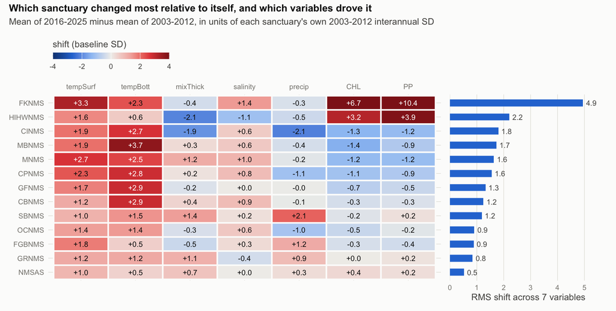

```r
d1    <- d_dep |> filter(baseline == "2003-2012")
ord   <- d1 |> arrange(rms) |> pull(nms)
d_var <- d1 |>
  pivot_longer(all_of(VARS), names_to = "var", values_to = "shift") |>
  mutate(nms = factor(nms, ord), var = factor(var, VARS))

p1 <- ggplot(d_var, aes(var, nms)) +
  geom_tile(aes(fill = pmax(pmin(shift, 4), -4)), color = PAL$surface, linewidth = 0.8) +
  geom_text(aes(label = sprintf("%+.1f", shift),
                color = abs(shift) > 2.4), size = 2.9, show.legend = FALSE) +
  scale_color_manual(values = c(`TRUE` = "white", `FALSE` = PAL$ink)) +
  scale_fill_gradientn(
    colors = PAL_DIV, limits = c(-4, 4), name = "shift (baseline SD)",
    guide = guide_colorbar(barwidth = 9, barheight = 0.5, title.position = "top")) +
  scale_x_discrete(position = "top") +
  labs(x = NULL, y = NULL) +
  theme_chk() +
  theme(panel.grid = element_blank())
p2 <- ggplot(d1 |> mutate(nms = factor(nms, ord)), aes(rms, nms)) +
  geom_col(fill = PAL$blue, width = 0.5) +
  geom_text(aes(label = sprintf("%.1f", rms)), hjust = -0.3, size = 2.9, color = PAL$ink2) +
  scale_x_continuous(expand = expansion(mult = c(0, 0.18))) +
  labs(x = "RMS shift across 7 variables", y = NULL) +
  theme_chk() +
  theme(axis.text.y = element_blank(), panel.grid.major.y = element_blank())
p <- (p1 | p2) +
  plot_layout(widths = c(3, 1.2)) +
  plot_annotation(
    title = "Which sanctuary changed most relative to itself, and which variables drove it",
    subtitle = "Mean of 2016-2025 minus mean of 2003-2012, in units of each sanctuary's own 2003-2012 interannual SD",
    theme = theme_chk())
save_fig(p, "fig_departure.png", 9.5, 4.8)
```

## 7. A shared step in temperature

Surface temperature is available from 1993 and does not depend on the ocean-color record. For each sanctuary, a single-step model of the annual anomaly (break year estimated, with a BIC penalty for estimating it) is compared with a linear trend.

```r
d_sst <- d_wide |>
  filter(date >= as_date("1993-01-01"), date <= as_date("2025-12-31")) |>
  select(nms, date, tempSurf) |>
  drop_na() |>
  mutate(mo = month(date), yr = year(date)) |>
  group_by(nms, mo) |>
  mutate(anom = tempSurf - mean(tempSurf[yr <= 2012])) |>
  group_by(nms, yr) |>
  summarize(anom = mean(anom), n = n(), .groups = "drop") |>
  filter(n == 12)

d_step <- d_sst |>
  group_by(nms) |>
  group_modify(\(d, k) {
    n     <- nrow(d)
    cand  <- d$yr[6:(n - 4)]                       # at least 5 years on either side
    bic_s <- sapply(cand, \(y) BIC(lm(anom ~ I(yr >= y), d)) + log(n))
    y     <- cand[which.min(bic_s)]
    m_tr  <- lm(anom ~ yr, d)
    pre   <- d$anom[d$yr < y]
    post  <- d$anom[d$yr >= y]
    tibble(
      step_year  = y,
      step_C     = mean(post) - mean(pre),
      step_sd    = (mean(post) - mean(pre)) / sd(pre),
      mean_pre   = mean(pre),
      mean_post  = mean(post),
      yrs_above_pre_max = glue("{sum(post > max(pre))} of {length(post)}"),
      bic_trend  = BIC(m_tr),
      bic_step   = min(bic_s),
      better     = case_when(
        bic_step < bic_trend - 2 ~ "step",
        bic_trend < bic_step - 2 ~ "trend",
        TRUE                     ~ "neither"))
  }) |>
  ungroup() |>
  mutate(nms = factor(nms, NMS_ORD)) |>
  arrange(nms)

d_step |>
  mutate(across(c(step_C, step_sd, bic_trend, bic_step), \(x) round(x, 2))) |>
  select(nms, `best step year` = step_year, `step (°C)` = step_C, `step (pre-step SD)` = step_sd,
         `post-step years above pre-step maximum` = yrs_above_pre_max,
         `BIC trend` = bic_trend, `BIC step` = bic_step, `better model` = better) |>
  kable(caption = "Annual surface-temperature anomaly, 1993-2025 (vs 1993-2012 monthly climatology): single step vs linear trend")
```

Annual surface-temperature anomaly, 1993-2025 (vs 1993-2012 monthly climatology): single step vs linear trend

| nms | best step year | step (°C) | step (pre-step SD) | post-step years above pre-step maximum | BIC trend | BIC step | better model |
| --- | --- | --- | --- | --- | --- | --- | --- |
| OCNMS | 2014 | 0.53 | 1.02 | 0 of 12 | 58.64 | 54.11 | step |
| GFNMS | 2014 | 0.74 | 1.33 | 2 of 12 | 71.84 | 63.90 | step |
| CBNMS | 2014 | 0.54 | 0.97 | 2 of 12 | 72.87 | 70.10 | step |
| MBNMS | 2014 | 0.90 | 1.77 | 3 of 12 | 71.20 | 59.94 | step |
| CPNMS | 2014 | 0.85 | 1.69 | 2 of 12 | 72.99 | 62.67 | step |
| CINMS | 2014 | 0.73 | 1.43 | 2 of 12 | 69.56 | 61.42 | step |
| HIHWNMS | 2014 | 0.65 | 1.92 | 4 of 12 | 34.90 | 25.67 | step |
| NMSAS | 2016 | 0.32 | 1.28 | 6 of 10 | 2.48 | 6.81 | trend |
| FGBNMS | 2015 | 0.69 | 2.26 | 6 of 11 | 26.09 | 22.06 | step |
| FKNMS | 2014 | 0.66 | 2.79 | 11 of 12 | 24.32 | 14.09 | step |
| GRNMS | 2000 | -0.34 | -1.16 | 1 of 26 | 41.67 | 41.06 | neither |
| MNMS | 2014 | 1.15 | 1.49 | 9 of 12 | 85.29 | 77.21 | step |
| SBNMS | 2010 | 0.91 | 2.42 | 12 of 16 | 50.05 | 45.23 | step |

Is a shared step distinguishable from a linear warming trend plus red noise? Surrogates keep each sanctuary’s linear trend, the spectrum of its residuals and the correlations among sanctuaries (common random phases), and contain no step.

```r
step_null_csv <- file.path(dir_chk, "sst_step_null.csv")
X_sst <- d_sst |>
  select(nms, yr, anom) |>
  pivot_wider(names_from = nms, values_from = anom) |>
  arrange(yr)
yrs   <- X_sst$yr
X_sst <- as.matrix(X_sst[, NMS_ORD])
n_y   <- nrow(X_sst)
cand  <- 6:(n_y - 4)

# best single-step year and delta bic (trend minus step; positive favors a step)
step_stat <- function(x) {
  bic    <- \(rss, k) n_y * log(rss / n_y) + k * log(n_y)
  rss_tr <- sum(resid(lm(x ~ yrs))^2)
  rss_st <- sapply(cand, \(i) sum((x[1:(i - 1)] - mean(x[1:(i - 1)]))^2) + sum((x[i:n_y] - mean(x[i:n_y]))^2))
  j      <- which.min(rss_st)
  c(year = yrs[cand[j]], dbic = bic(rss_tr, 3) - bic(rss_st[j], 4))
}
obs_step <- apply(X_sst, 2, step_stat)

if (!file.exists(step_null_csv)) {
  set.seed(42)
  fit_tr <- lm(X_sst ~ yrs)
  Tr     <- fitted(fit_tr)
  R      <- resid(fit_tr)
  sur    <- function() {
    k   <- floor((n_y - 1) / 2)
    ph  <- runif(k, 0, 2 * pi)
    rot <- rep(1 + 0i, n_y)
    rot[2:(k + 1)]       <- exp(1i * ph)
    rot[n_y:(n_y - k + 1)] <- exp(-1i * ph)
    Tr + Re(mvfft(mvfft(R) * rot, inverse = TRUE)) / n_y
  }
  map_dfr(seq_len(5000), \(b) {
    S <- apply(sur(), 2, step_stat)
    as_tibble(as.list(S["dbic", ])) |>
      mutate(
        rep     = b,
        modal   = max(table(S["year", ])),
        n_step  = sum(S["dbic", ] > 2),
        n_2014  = sum(S["year", ] == 2014))
  }) |>
    write_csv(step_null_csv)
}
d_sn <- read_csv(step_null_csv)

tibble(
  nms          = NMS_ORD,
  `step year`  = obs_step["year", ],
  `delta BIC`  = round(obs_step["dbic", ], 1),
  `surrogate p` = map_dbl(NMS_ORD, \(x) mean(d_sn[[x]] >= obs_step["dbic", x]))) |>
  mutate(`surrogate p` = round(`surrogate p`, 3)) |>
  kable(caption = "Step vs trend per sanctuary: share of trend-plus-red-noise surrogates with a delta BIC at least as large as observed")
```

Step vs trend per sanctuary: share of trend-plus-red-noise surrogates with a delta BIC at least as large as observed

| nms | step year | delta BIC | surrogate p |
| --- | --- | --- | --- |
| OCNMS | 2014 | 4.5 | 0.228 |
| GFNMS | 2014 | 7.9 | 0.079 |
| CBNMS | 2014 | 2.8 | 0.282 |
| MBNMS | 2014 | 11.3 | 0.026 |
| CPNMS | 2014 | 10.3 | 0.068 |
| CINMS | 2014 | 8.1 | 0.091 |
| HIHWNMS | 2014 | 9.2 | 0.026 |
| NMSAS | 2016 | -4.3 | 0.773 |
| FGBNMS | 2015 | 4.0 | 0.153 |
| FKNMS | 2014 | 10.2 | 0.091 |
| GRNMS | 2000 | 0.6 | 0.784 |
| MNMS | 2014 | 8.1 | 0.049 |
| SBNMS | 2010 | 4.8 | 0.039 |

```r
obs_modal <- max(table(obs_step["year", ]))
obs_nstep <- sum(obs_step["dbic", ] > 2)
tibble(
  statistic = c(
    "sanctuaries sharing the modal step year",
    "sanctuaries where BIC prefers a step (delta BIC > 2)",
    "sum of delta BIC over sanctuaries"),
  observed  = c(obs_modal, obs_nstep, round(sum(obs_step["dbic", ]), 1)),
  `surrogate median` = c(median(d_sn$modal), median(d_sn$n_step), round(median(rowSums(d_sn[, NMS_ORD])), 1)),
  `surrogate 95th percentile` = c(
    quantile(d_sn$modal, 0.95), quantile(d_sn$n_step, 0.95), round(quantile(rowSums(d_sn[, NMS_ORD]), 0.95), 1)),
  `surrogate p` = c(
    mean(d_sn$modal >= obs_modal), mean(d_sn$n_step >= obs_nstep),
    mean(rowSums(d_sn[, NMS_ORD]) >= sum(obs_step["dbic", ])))) |>
  kable(caption = "System-level test of a shared step (5000 surrogates)")
```

System-level test of a shared step (5000 surrogates)

| statistic | observed | surrogate median | surrogate 95th percentile | surrogate p |
| --- | --- | --- | --- | --- |
| sanctuaries sharing the modal step year | 9.0 | 5.0 | 7.0 | 0.0126 |
| sanctuaries where BIC prefers a step (delta BIC > 2) | 11.0 | 6.0 | 10.0 | 0.0176 |
| sum of delta BIC over sanctuaries | 77.6 | 18.3 | 64.4 | 0.0208 |

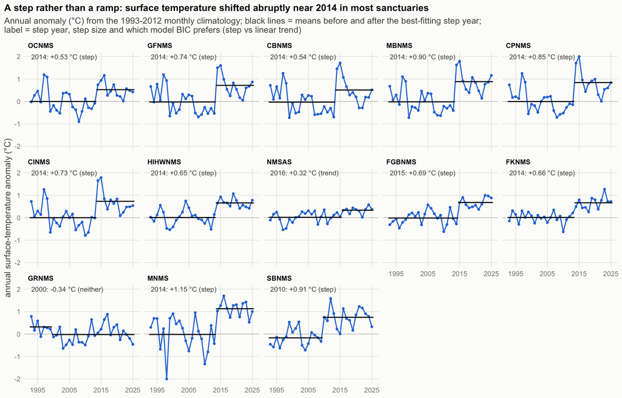

```r
d_seg <- d_step |>
  transmute(
    nms, step_year,
    lab = glue("{step_year}: {sprintf('%+.2f', step_C)} °C ({better})"),
    x1 = 1992.5, x2 = step_year - 0.5, x3 = 2025.5, mean_pre, mean_post)

p <- d_sst |>
  mutate(nms = factor(nms, NMS_ORD)) |>
  ggplot(aes(yr, anom)) +
  geom_hline(yintercept = 0, color = PAL$axis, linewidth = 0.3) +
  geom_line(color = PAL$blue, linewidth = 0.6) +
  geom_point(color = PAL$blue, size = 0.9) +
  geom_segment(data = d_seg, aes(x = x1, xend = x2, y = mean_pre,  yend = mean_pre),  color = PAL$ink, linewidth = 0.6) +
  geom_segment(data = d_seg, aes(x = x2, xend = x3, y = mean_post, yend = mean_post), color = PAL$ink, linewidth = 0.6) +
  geom_text(data = d_seg, aes(x = 1993, y = Inf, label = lab), hjust = 0, vjust = 1.4, size = 2.8, color = PAL$ink2) +
  facet_wrap(~nms, ncol = 5) +
  scale_x_continuous(breaks = c(1995, 2005, 2015, 2025)) +
  labs(
    title = "A step rather than a ramp: surface temperature shifted abruptly near 2014 in most sanctuaries",
    subtitle = "Annual anomaly (°C) from the 1993-2012 monthly climatology; black lines = means before and after the best-fitting step year;\nlabel = step year, step size and which model BIC prefers (step vs linear trend)",
    x = NULL, y = "annual surface-temperature anomaly (°C)") +
  theme_chk()
save_fig(p, "fig_sst_step.png", 10, 6.4)
```

## 8. Product checks that bear on “regime shifts”

```r
z |>
  mutate(era = cut(yr, c(1997, 2002, 2011, 2016, 2026), labels = c(
    "1998-2002 (SeaWiFS only)", "2003-2011 (+MODIS, MERIS)", "2012-2016 (+VIIRS)", "2017-2025 (+OLCI)"))) |>
  group_by(nms, era) |>
  summarize(CHL = round(mean(CHL), 2), .groups = "drop") |>
  pivot_wider(names_from = era, values_from = CHL) |>
  mutate(nms = factor(nms, NMS_ORD)) |>
  arrange(nms) |>
  kable(caption = "Mean standardized chlorophyll anomaly by ocean-color sensor era. A step shared by sanctuaries in different basins points to the merged product, not the ocean.")
```

Mean standardized chlorophyll anomaly by ocean-color sensor era. A step shared by sanctuaries in different basins points to the merged product, not the ocean.

| nms | 1998-2002 (SeaWiFS only) | 2003-2011 (+MODIS, MERIS) | 2012-2016 (+VIIRS) | 2017-2025 (+OLCI) |
| --- | --- | --- | --- | --- |
| OCNMS | -0.02 | 0.11 | 0.04 | -0.12 |
| GFNMS | -0.44 | 0.33 | 0.01 | -0.09 |
| CBNMS | -0.28 | 0.25 | -0.12 | -0.02 |
| MBNMS | -0.52 | 0.45 | -0.15 | -0.08 |
| CPNMS | -0.58 | 0.45 | -0.25 | 0.01 |
| CINMS | -0.47 | 0.59 | -0.45 | -0.08 |
| HIHWNMS | -0.49 | -0.17 | -0.53 | 0.75 |
| NMSAS | -0.23 | -0.05 | 0.14 | 0.10 |
| FGBNMS | -0.31 | 0.32 | -0.28 | 0.01 |
| FKNMS | -0.57 | -0.58 | -0.03 | 0.94 |
| GRNMS | -0.52 | 0.21 | -0.01 | 0.09 |
| MNMS | -0.17 | 0.46 | -0.23 | -0.24 |
| SBNMS | -0.05 | 0.02 | 0.07 | -0.03 |

```r
z |>
  mutate(era = cut(yr, c(1997, 2002, 2006, 2013, 2016, 2021, 2026),
                   labels = c("1998-02", "2003-06", "2007-13", "2014-16", "2017-21", "2022-25"))) |>
  group_by(era) |>
  summarize(across(all_of(VARS), \(x) round(mean(x), 2)), .groups = "drop") |>
  kable(caption = "Mean standardized anomaly by period, averaged over all 13 sanctuaries")
```

Mean standardized anomaly by period, averaged over all 13 sanctuaries

| era | tempSurf | tempBott | mixThick | salinity | precip | CHL | PP |
| --- | --- | --- | --- | --- | --- | --- | --- |
| 1998-02 | -0.36 | -0.31 | 0.10 | 0.05 | -0.07 | -0.36 | -0.32 |
| 2003-06 | -0.15 | -0.32 | -0.11 | -0.45 | 0.08 | 0.27 | 0.26 |
| 2007-13 | -0.47 | -0.40 | 0.04 | 0.10 | 0.00 | 0.05 | 0.01 |
| 2014-16 | 0.78 | 0.65 | -0.03 | 0.00 | 0.11 | -0.17 | -0.17 |
| 2017-21 | 0.38 | 0.41 | 0.03 | 0.13 | -0.01 | 0.12 | 0.17 |
| 2022-25 | 0.39 | 0.43 | -0.11 | 0.05 | -0.05 | 0.06 | 0.05 |

```r
z |>
  group_by(nms) |>
  summarize(
    `r(CHL, PP)`             = round(cor(CHL, PP), 2),
    `r(tempSurf, tempBott)`  = round(cor(tempSurf, tempBott), 2),
    .groups = "drop") |>
  mutate(nms = factor(nms, NMS_ORD)) |>
  arrange(nms) |>
  kable(caption = "Redundancy among response variables (monthly standardized anomalies)")
```

Redundancy among response variables (monthly standardized anomalies)

| nms | r(CHL, PP) | r(tempSurf, tempBott) |
| --- | --- | --- |
| OCNMS | 0.88 | 0.78 |
| GFNMS | 0.91 | 0.77 |
| CBNMS | 0.91 | 0.56 |
| MBNMS | 0.94 | 0.83 |
| CPNMS | 0.94 | 0.67 |
| CINMS | 0.96 | 0.70 |
| HIHWNMS | 0.86 | 0.58 |
| NMSAS | 0.87 | 0.20 |
| FGBNMS | 0.87 | 0.42 |
| FKNMS | 0.93 | 0.90 |
| GRNMS | 0.95 | 0.94 |
| MNMS | 0.94 | 0.65 |
| SBNMS | 0.90 | 0.69 |

```r
d_wide |>
  filter(date >= as_date("1998-01-01"), date <= as_date("2025-09-30")) |>
  mutate(mo = month(date)) |>
  group_by(nms, mo) |>
  summarize(across(all_of(VARS), \(x) sd(x, na.rm = T) < 1e-8), .groups = "drop") |>
  pivot_longer(all_of(VARS), names_to = "var") |>
  filter(value) |>
  select(nms, var, month = mo) |>
  kable(caption = "Sanctuary × calendar-month × variable cells with zero variance (e.g., mixed-layer depth pinned at the model's shallowest level)")
```

Sanctuary × calendar-month × variable cells with zero variance (e.g., mixed-layer depth pinned at the model’s shallowest level)

| nms | var | month |
| --- | --- | --- |
| SBNMS | mixThick | 7 |